# R course

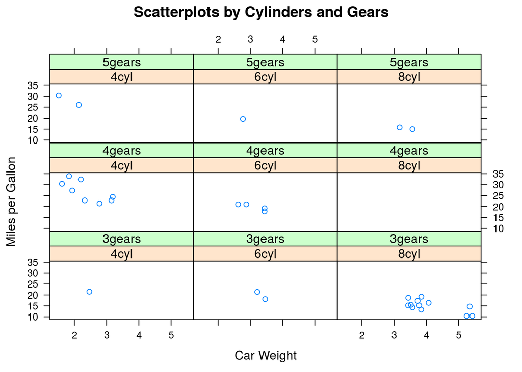

```r
# scatterplots for each combination of two factors
xyplot(mpg ~ wt | cyl.f * gear.f,
       main="Scatterplots by Cylinders and Gears",
       ylab="Miles per Gallon", xlab="Car Weight")
```

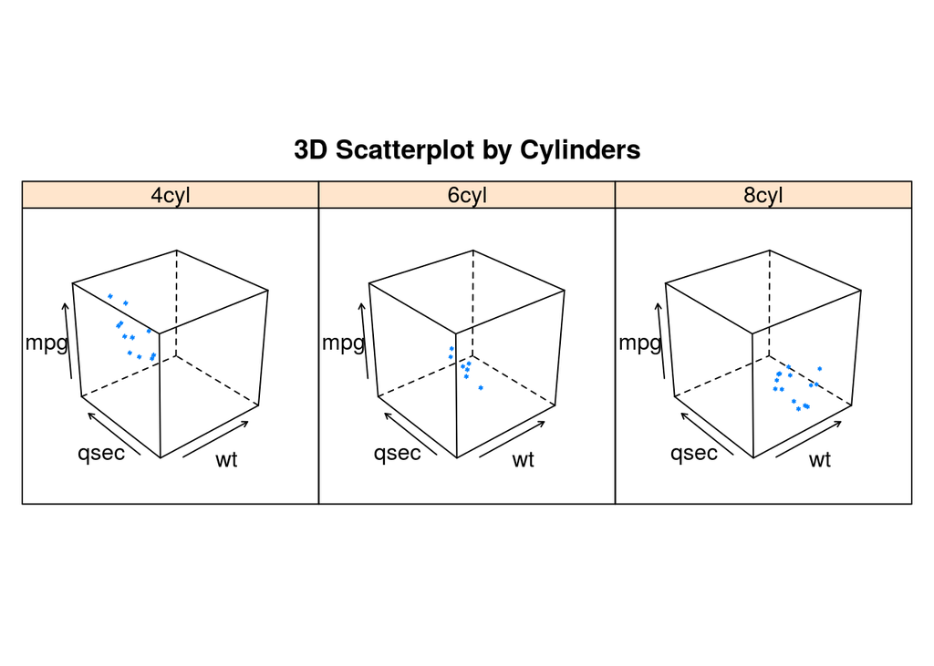

```r
# 3d scatterplot by factor level
cloud(mpg ~ wt * qsec | cyl.f,
      main="3D Scatterplot by Cylinders")
```

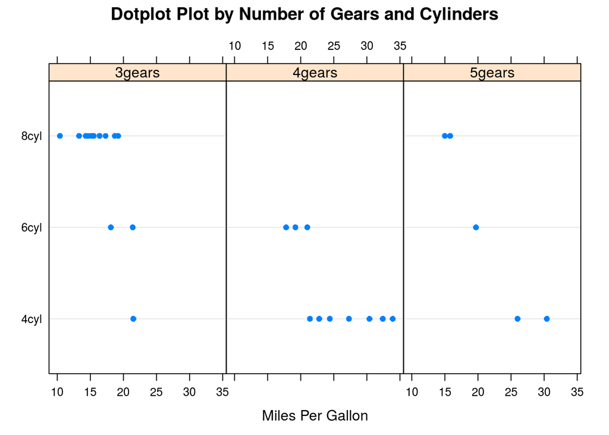

```r
# dotplot for each combination of two factors
dotplot(cyl.f ~ mpg | gear.f,
        main="Dotplot Plot by Number of Gears and Cylinders",
        xlab="Miles Per Gallon")
```

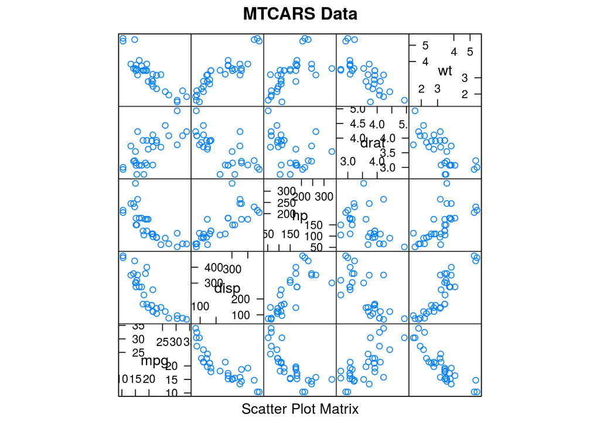

```r
# scatterplot matrix
splom(mtcars[c(1,3,4,5,6)],
      main="MTCARS Data")
```

```r
detach()
```

Voir http://lmdvr.r-forge.r-project.org/figures/figures.html

## ggplot2

ggplot2 est une librairie graphique plus récente. Permet de faire des graphiques esthétiques, mais plus difficile à controler finement qu’avec graphics ou lattice.

### qplot

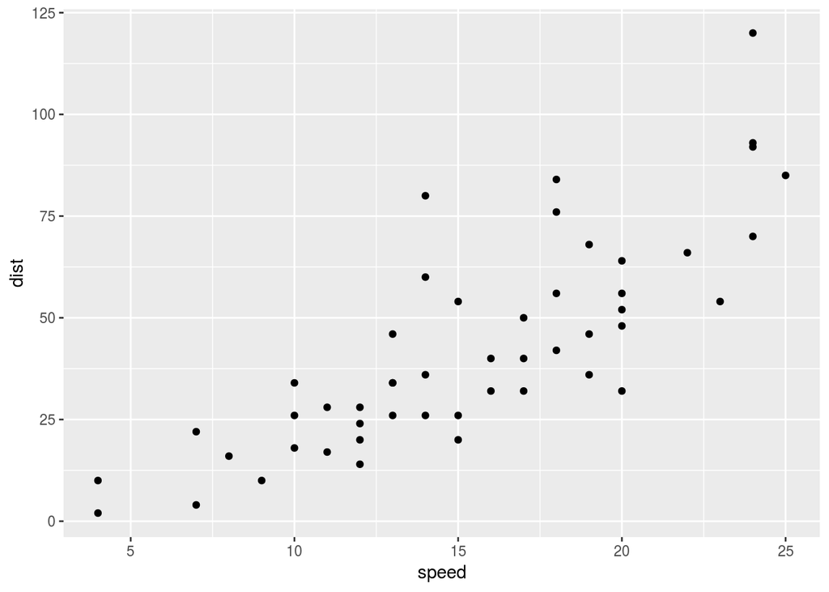

```r
require(ggplot2)
data(cars)
qplot(speed, dist, data=cars)
```

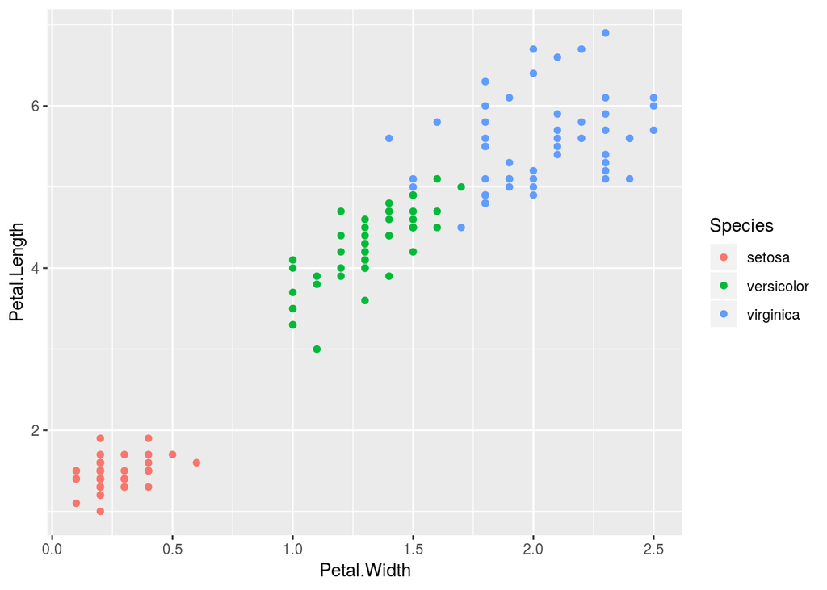

```r
data(iris)
qplot(Petal.Width, Petal.Length, color = Species, data=iris)
```

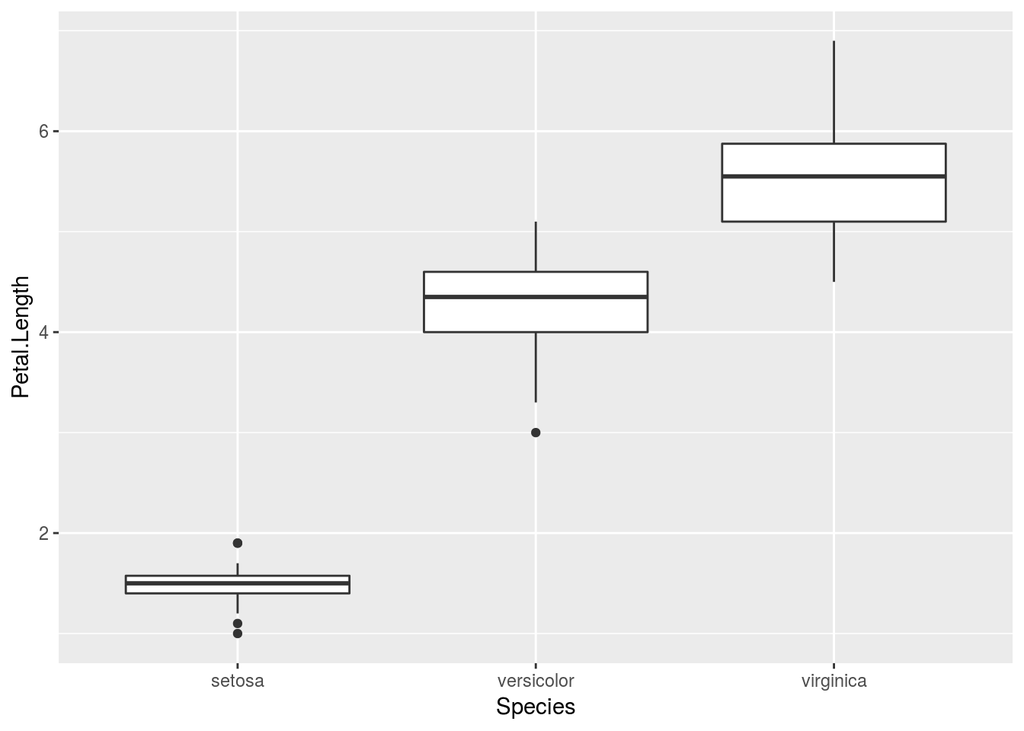

```r
data(iris)
qplot(Species, Petal.Length, geom='boxplot', data=iris)
```

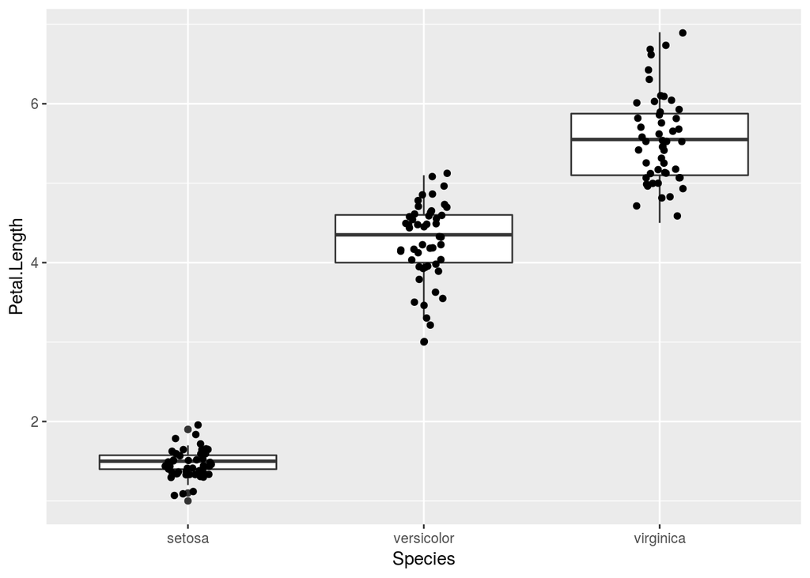

```r
data(iris)
ggplot(iris, aes(x = Species, y = Petal.Length)) + geom_boxplot() + geom_jitter(width=0.1, height=0.1)
```

**Tutorials and books on ggplot**

- [Complete ggplot2 tutorial](http://r-statistics.co/Complete-Ggplot2-Tutorial-Part1-With-R-Code.html) de Selva Prabhakaran
- [R graphics cookbook](http://www.cookbook-r.com/) de Winston Chang
- *Applied Data Visualization with R and ggplot2* (https://github.com/TrainingByPackt/Applied-Data-Visualization-with-R-and-ggplot2)
- https://ggplot2.tidyverse.org/reference/

# Quelques exemples simples d’analyses de données

- [Examples of basic data analyses with R](http://www.pallier.org/examples-of-basic-data-analyses-with-r.html)
- [Easy ANOVA](http://www.pallier.org/easy-anova-with-r.html)

Voir également le document `stats_with_R.Rmd``

# Exercices d’analyse de données (simples)

### Dossier sommeil

Lors d’une expérimentation médicale, on a relevé le temps de sommeil T de 10 patients (facteur Sujet) sous l’effet de deux médicaments (d’où le facteur Médicament M). Chaque sujet a pris successivement l’un et l’autre des deux médicaments.

- Source: Student (1908) The probable error of a mean, *Biometrika*, VI, 1-25.
- Données `sommeil.txt`
- Question: Ces données ont été recueillies pour tester l’hypothèse que le médicament m2 est plus efficace que le médicament m1. Est-ce le cas?

### Dossier pédagogie

Lors d’une expérimentation pédagogique, on désire comparer l’efficacité de quatre méthodes d’enseignements.

On dispose des notes obtenues à un examen par quatre groupes d’élèves ayant chacun reçu un des 4 types d’enseignements (Données fictives).

- Données: `pedago.txt`
- Question: Comparer les résultats obtenus en fonction des méthodes.

### Dossier négligence

Une recherche a porté sur la “pseudo-négligence” qu’on observe chez des sujets normaux. Ce nom provient des similarités qu’elle présente avec l’hémi-négligence (atteinte de la moitié du champ visuel) de sujets atteints d’une lésion cérébrale. La tâche des sujets consiste à déterminer le milieu subjectif d’une baguette de 24cm avec la seule aide d’informations kinesthésiques. La pseudo-négligence se traduit par une déviation systématique vers la droite (pour les droitiers) de ce milieu subjectif par rapport au milieu objectif de la baguette.

Les données portent sur 24 femmes droitières (facteur S) réparties selon 2 conditions (12 sujets pour chacune): active (c1) où le sujet peut librement déplacer son doigt posé sur un curseur mobile le long de la baguette; ou passive (c2) où le sujet commande un moteur déclenchant le mouvement de la baguette dans un sens ou dans l’autre, alors que son doigt ne bouge pas (facteur C). Chaque sujet exécute cette tâche dans 6 situations expérimentales obtenues par le croisement de: la main utilisée, gauche (m1) ou droite (m2); et l’orientation du regard, 30° à gauche (o1), 0° (o2) ou 30° à droite (o3) (facteurs M et O). Pour chaque sujet et chaque situation on mesure la déviation en cm entre le milieu subjectif et le milieu objectif de la baguette. Une déviation à droite est notée par une valeur positive, à gauche par une valeur négative.

On s’intéresse ici à l’effet de la condition (C) lorsque le sujet utilise sa main habituelle (m2) (Rappel : tous les sujets sont droitiers) et lorsqu’il se trouve en face du milieu de la baguette (avec l’orientation à 0 degrés)

### Dossier family

Etude réalisée au USA sur les origines des stéréotypes liés au sexe. 35 familles choisies au hasard et ayant une fille ainée (ou fille unique) en Troisième.

Le père a répondu à un questionnaire sur ses intérêts pour le sport, noté sur une échelle numérique de 0 à 50 (FATH)

La mère a répondu au même questionnaire (MOTH)

Le professeur d’éducation physique de chacune des filles a noté les performances physiques générales de la fille de 0 à 20 (PROF).

La fille a répondu également au questionnaire d’inérêt pour le sport (GIRL).

### Dossier IO

En 1980, on a interrogé des lycéens (garçons et filles) sur leurs intentions d’orientation après le bac (études scientifiques, littéraires ou techniques).

- Source: Il s’agit de données en partie fictives, inspirées d’un exemple de M. Reuchlin.
- Données: `io.txt`
- Questions: Peut-on dire que l’orientation envisagée est liée au sexe chez l’ensemble des lycéens de cette année 1980 ?

More about `ggplot2`:

- https://www.stat.ubc.ca/~jenny/STAT545A/block18_gapminderGgplot2VsLattice.html
- https://learnr.wordpress.com/2009/06/28/ggplot2-version-of-figures-in-lattice-multivariate-data-visualization-with-r-part-1/
- https://learnr.wordpress.com/2009/06/29/ggplot2-version-of-figures-in-lattice-multivariate-data-visualization-with-r-part-2/
- https://learnr.wordpress.com/2009/07/02/ggplot2-version-of-figures-in-lattice-multivariate-data-visualization-with-r-part-3/
- https://learnr.wordpress.com/2009/07/02/ggplot2-version-of-figures-in-lattice-multivariate-data-visualization-with-r-part-4/
- https://learnr.wordpress.com/2009/07/15/ggplot2-version-of-figures-in-lattice-multivariate-data-visualization-with-r-part-5/
- https://learnr.wordpress.com/2009/07/20/ggplot2-version-of-figures-in-lattice-multivariate-data-visualization-with-r-part-6/
- https://learnr.wordpress.com/2009/07/27/ggplot2-version-of-figures-in-lattice-multivariate-data-visualization-with-r-part-7/
- https://learnr.wordpress.com/2009/08/03/ggplot2-version-of-figures-in-lattice-multivariate-data-visualization-with-r-part-8/
- https://learnr.wordpress.com/2009/08/26/ggplot2-version-of-figures-in-lattice-multivariate-data-visualization-with-r-final-part/

# Solutions des exercices

- créer le vecteur 1 2 2 3 3 3 4 4 4 4 5 5 5 5 5 … 100

  rep(1:100, 1:100)
- calculer la somme des 1000 premiers nombres entiers

  sum(1:1000)
- calculer factorielle de 20

  prod(1:20)
- calculer la proportion d’éléments négatifs dans un vecteur.

- Etant donné un fichier texte, calculer le nombre de mots distinct qu’il contient, et pour chacun de ces mots, sa fréquence d’occurence dans le fichier.